# RMarkdown Class Schedule

Ken Kalbach

September 15, 2019

# Class Schedule

### STAT 414: Intro Prob Theory

This class is the introduction to the theory of probability in statistics, mathmatics, engineering, and other similar subjects. So far, I am enjoying the class, I like my professor and the material. I am taking this class because it is a prerequisit for many of the upper 400 level stat classes. My section meets twice a week at 9:05 am. If you want to know more about Stat 414, [here’s the link](https://newonlinecourses.science.psu.edu/stat414/). Since probability theory is heavily based in calculations, I’ve attached a photo of a tree diagram which is helpful to figure out different probabilities.

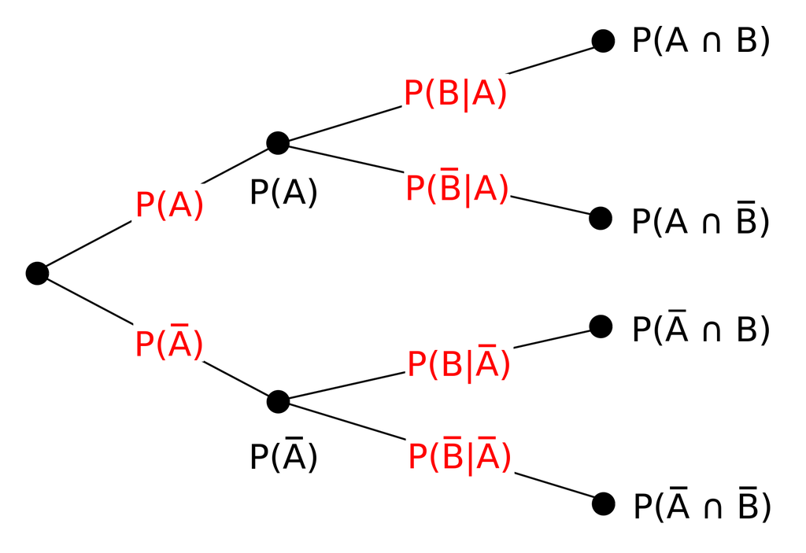

### STAT 184: Introduction to R Programmaing

This class in an introduction to the coding language R. R is a statistical based coding language used by professional statisticians to analyze data. I am taking this class because I am required to take this class. So far it’s not too bad, but I know the concepts will get more complex and my frustrations with myself will grow along with the more complex topics. If you want to know more about Stat 184, [here’s the link](https://stat.psu.edu/education/syllabi/spring-2017/stat184syllabus.pdf/view). Here is a photo of Bert and Earnie from Sesame Street holding the letter R:

[figure not shown]

### Stat 462: Applied Regression Analysis

This class is an in-depth class about regression analysis. In this class I will learn about linear regression, stepwise regression, and non-linear regression models as well as correlation. I am really enjoying this class and the topics that it is covering. This class meets three times a week. If you want to learn more about the class, [here’s the link](https://newonlinecourses.science.psu.edu/stat462/). Here is an example of a linear regression model:

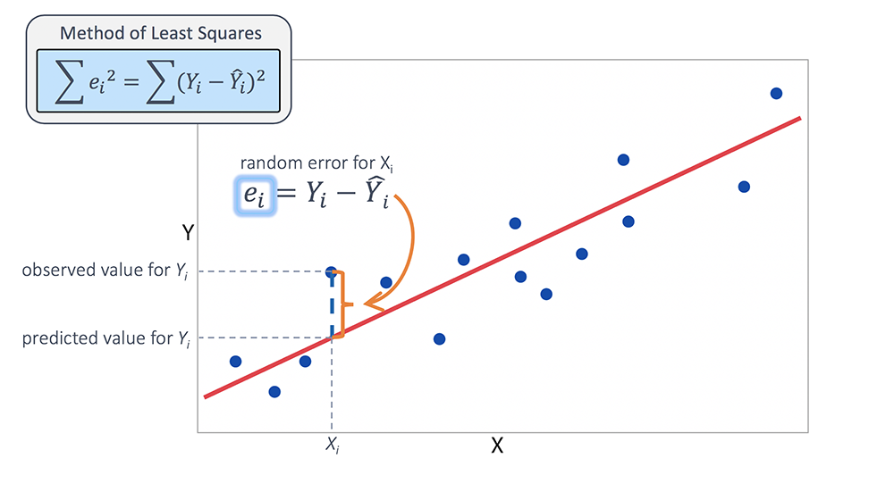